# Variables aléatoires

Diana Nurbakova

# Variable aléatoire : éventualité-gain

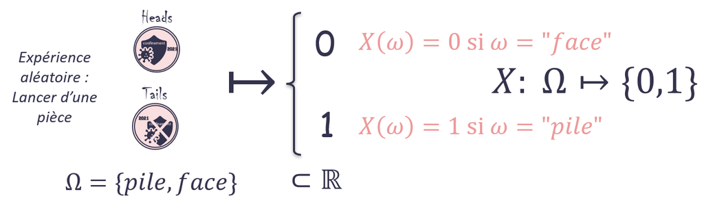

Imaginons qu’on met en place une expériance aléatoire en lançant une pièce. Les issues possibles sont $pile$ et $face$, autrement dit, l’univers est $\Omega = \{pile, face\}$. Ce dernier est plutôt abstrait et une telle représentation n’est pas toujours pratique pour les calculs.

Nous aimerions donc de ``quantifier” ces issues, en faisant une correspondance de ces issues aux nombres. L’application des issues à ce nouvel espace est une variable aléatoire. Ainsi, une variable aléatoire peut être considérée comme un résultat d’une expérience aléatoire qu’on peut mesurer ou compter.

Notons que dans ce contexte, le terme *variable* est différent de celui de l’algèbre. Une variable aléatoire peut prendre plusieurs valeurs avec différentes probabilités.

Notons aussi qu’une variable aléatoire peut être plus “complèxe” qu’un recodage directe d’issues en nombres, e.g. la somme de résultats de 5 lancers d’un dé cubique.

Soit $\mathcal{A}$ un ensemble d’évènements associés à l’univers $\Omega$, appelé **tribu** ou **$\sigma$-algèbre** (en. *$\sigma$-algebra*), vérifiant les propriétés suivantes :

- $\Omega \in \mathcal{A}$
- $A \in \mathcal {A} \Rightarrow A^c \in \mathcal{A}$
- $\forall i \in \mathbb{N}, 𝐴_i \in \mathcal{A} \Rightarrow \cup_{i\in \mathbb{N}} A_i \in \mathcal{A}$

Pour $\Omega$ fini ou infini dénombrable, on considère souvent $\mathcal{A} = \mathcal{P}(\Omega)$.

Pour $\Omega = \mathbb{R}$ : $\mathcal{A} = \mathcal{B}(\mathbb{R})$ où $\mathcal{B}(\mathbb{R})$ est un ensemble des Boréliens, i.e. l’ensemble des parties de $\mathbb{R}$ engendrés par les intervalles de $\mathbb{R}$.

Soit $(\Omega, \mathcal{A})$ un espace d’évènements de l’espace probabilisé $(\Omega, \mathcal{A}, \mathbb{P})$ et $(E, \mathcal{E})$ un espace mesurable. Une **variable aléatoire, v.a.** (en. *random variable, r.v.*) $X$ de $\Omega$ vers $E$ est une fonction mesurable :
$$X : \Omega \rightarrow E$$

telle que :

$$\forall A' \in \mathcal{E},
X^{-1}(A') \in \mathcal{A}$$

où $X^{-1}(A')$ est l’image réciproque $X^{-1}(A') = \{\omega\in \Omega | X(\omega)\in A'\}\in \mathcal{A}$.

Souvent, on va considérer le cas où $E \subset \mathbb{R}$. Une **variable aléatoire réelle, v.a.r.** (en. *real-valued random variable*) sur l’espace d’évènements $(\Omega, \mathcal{A})$ est une fonction mesurable $X : \Omega \rightarrow \mathbb{R}$, telle que :
$$\forall x\in \mathbb{R}, X^{-1}(]-\infty, x])\in
\mathcal{A}$$

**Remarque :** Pour la notation de variables aléatoires, les lettres majuscules sont utilisées par la convention.

> Quelles sont les valeurs de la v.a. $X$ ?

Selon la valeur qu’une variable aléatoire peut prendre, on distingue les différents types de variables aléatoires.

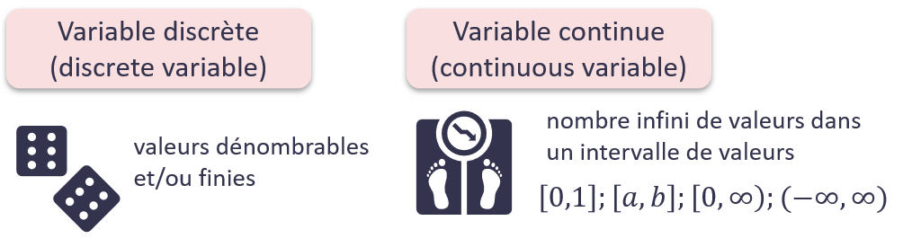

### Variable aléatoire discrète

Une v.a.r. $X$ est appelée **discrète** (en. *discrete r.v.*) si elle ne prend qu’un nombre dénombrable et/ou fini de valeurs dans $\mathbb{R}$, i.e. $X(\Omega) = \left\{x_j\in \mathbb{R}, j\in J\right\}$ avec $J \subset \mathbb{N}$.

### Variable aléatoire continue

Dans le cas générale, une v.a.r. $X$ est appelée **continue** (en. *continuous r.v.*) si son image est indénombrablement infinie (souvent un intervalle).

Dans le cas plus concret, il s’agit de la *continuité absolue* (au sens de Lebesgue).

Voici quelques exemples : $X =$ “*Le poids (exacte) d’un(e) étudiant(e) de l’INSA pris(e) au hasard*”, $X =$ “*La hauteur (exacte) franchie par l’athlète gagnant les sauts à la perche lors de prochains Jeux Olympiques*”, $X =$ “*Le niveau de réchauffement climatique atteint vers 2030*”.

# Fonction de répartition et Loi d’une variable aléatoire réelle

Un espace $(\Omega, \mathcal{A})$ est munie d’une mesure de probabilité $\mathbb{P}$ dans l’espace probabilisé $(\Omega, \mathcal{A}, \mathbb{P})$. Grâce à la mésurabilité de la variable aléatoire $X$, il est possible de définir la probabilité $\mathbb{P}_X: \mathcal{E} \rightarrow [0,1]$ (aussi appelée **la loi de probabilité de la v.a.r. $X$** ou juste **loi de la v.a.r. $X$** (en. *probability distribution*)) sur l’espace mesurable $(E, \mathcal{E})$ :
$$\forall A'\in \mathcal{E}, \ \
\mathbb{P}_X(A') = \mathbb{P}(X^{-1}(A')) = \mathbb{P}(X\in
A')$$

Ainsi, une loi de probabilité est une fonction qui décrit la probabilité d’occurrence d’issues possibles de l’expérience aléatoire.

> Comment est-ce que la v.a.r. $X$ est réparti ?

Pour définir la répartition d’une v.a.r. les différentes représentations peuvent être utilisés comme : des graphes, des tables (surtout dans le cas d’une v.a. discrète), des fonctions.

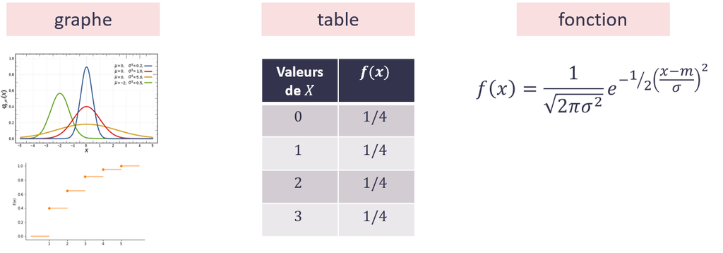

Dans le cas général, on peut parler de la fonction de répartition qui caractérise la loi de probabilité.

Soit $X$ une v.a.r. sur l’espace probabilisé $(\Omega, \mathcal{A}, \mathbb{P})$. On appelle **la fonction de répartition d’une v.a.r. $X$** (en. *cumulative distribution function*) ou **la fonction de distribution cumulative d’une v.a.r. $X$** l’application $F_X$ qui à $\forall x\in \mathbb{R}$ associe la probabilité d’obtenir une valeur inférieure ou égale à $x$, i.e. :
$$F_X: \ \left.
\begin{array}{ll}
\mathbb{R}\rightarrow [0,1] \\
x \rightarrow \mathbb{P}(X^{-1}(]-\infty,x]))
\end{array}
\right.$$
Autrement dit, $F_X(x) = \mathbb{P}(X\leq x)$.

Les propriétés de base de la fonction de répartition d’une v.a.r. :

- $F_X$ est toujours croissante, i.e. $\forall (a,b)\in \mathbb{R}^2,\ a \leq b \Rightarrow F_X(a) \leq F_X(b)$
- $F_X$ est continue à droite
- $\lim\limits_{x\rightarrow-\infty} F_X(x) = 0$ et $\lim\limits_{x\rightarrow+\infty} F_X(x) = 1$

Notons que $F_X$ est une fonction monotonne bornée :
$$\forall x\in \mathbb{R},
\ 0\leq F_X(x)\leq 1$$

La fonction de répartition permet de calculer la probabilité d’une v.a.r. $X$ d’être incluse dans un intervalle semi-ouvert à gauche $]a,b]$ où $a < b$ comme suit :
$$\mathbb{P}(X
\in ]a,b]) = \mathbb{P}(a < X \leq b) = F_X(b)-F_X(a)$$

## Variables discrètes

### Fonction de masse

Supposons qu’on s’intéresse au nombre de tasses de café qu’un étudiant prend avant la pause midi. Dans le tableau, on présente toutes les valeurs à probabilité non nulle. Dans notre cas, ce sont : $1$, $2$, $3$, $4$, $5$. Supposons aussi qu’on connait la probabilité de chacune de ses valeurs. Ecrivons-les dans le même tableau.

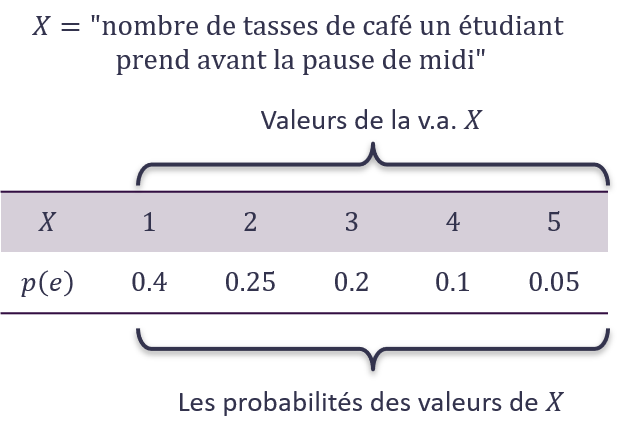

Soit $X$ une v.a.r. discrète, $X(\Omega) = \left\{x_j\in \mathbb{R}, j\in J\right\}$ avec $J \subset \mathbb{N}$. **La fonction de masse de la v.a.r. $X$** (en. *probability mass function, pmf*) est une application $p$ telle que :
$$p \ \left.
\begin{array}{ll}
J\rightarrow [0,1] \\
j \rightarrow p_j
\end{array}
\right.$$
où $p_j = \mathbb{P}(X = x_j)$, en considérant que $\forall j \in \mathbb{N}\setminus J, \ p_j = 0$.

La fonction de masse $p$ a des propriétés suivantes :

- $\forall j\in J, \ p_j \geq 0,\ p_j \in [à,1]$
- $\sum\limits_{j \in \mathbb{N}} p_j = 1$

Vérifions que les valeurs présentées dans le tableau forment une fonction de masse valide :

$$\sum_{i=1}^n p(x_i) = 0.4 + 0.25 + 0.2 +
0.1 + 0.05 = \mathbf{1}$$
et toutes $p_j \geq 0$.

Les conditions sont bien satisfaites.

On peut représenter la fonction de masse de $X$ sous forme d’un graphique :

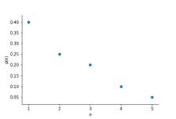

### Fonction de répartition

Regardons maintenant comment on peut définir la fonction de répartition d’une v.a.r. discrète.

Comme précisé avant, la fonction de répartition est une fonction cumulative. Dans le cas d’une v.a.r. discrète :

[figure not shown]

Ainsi, nous obtenons les valeurs suivantes :

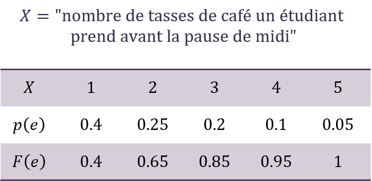

Soit $X$ une v.a.r. discrète. Pour tout $k \in \mathbb{N}$ :
$$F_X(x) = \sum_{i=1}^k p_i$$

Représentons la fonction de répartition sous forme de graphique :

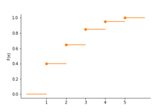

La fonction de répartition d’une v.a.r. discrète est constante par morceaux et admet les points de discontinuité $\{x_j, j\in J\}$

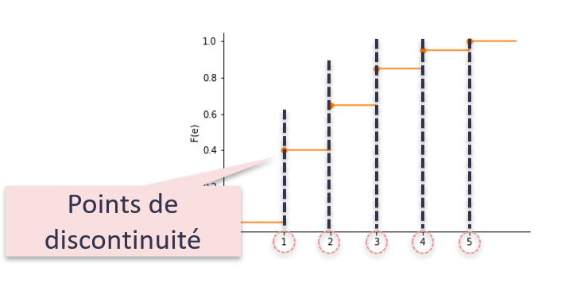

#### Caractérisation de la loi d’une v.a.r. discrète par la fonction de masse

Notons que la fonction de masse $p$ caractérise la loi d’une v.a.r. discrète $X$. Dans le cas d’une v.a.r. discrète $X$ définie sur $(\Omega, \mathcal{A}, \mathbb{P})$ :
$$\mathbb{P}_X(A) = \sum_{j\in
\mathbb{N}}\left(\mathbb{P}(X=x_j)\times \mathbb{I}_A(x_j)\right) =
\sum_{j\in \mathbb{N}}\left(p_j\times \mathbb{I}_A(x_j)\right)$$
où $A$ est un borélien de $\mathbb{R}$, $\mathbb{I}_A(x) = \left\{ \begin{array}{ll} 1 \mbox{ si } x\in A \\ 0 \mbox{ si } x\notin A \end{array}\right.$ est la fonction indicatrice de l’ensemble $A$.

## Variables continues

### Fonction de densité

Soit $X$ un v.a.r. absolument continue. **La fonction de densité** ou **densité de probabilité** (en. *probability density function, pdf*) $f_X(x)$ est une fonction positive et intégrable sur $\mathbb{R}$, telle que :
$$\mathbb{P}(a\leq X\leq b) =
\int_{a}^{b}f(t)dt$$

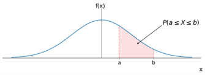

Notons que :
$$f_X(x) =
\frac{d}{dx}F_X(x)$$
presque partout.

Les propriétés :

- $\forall t\in \mathbb{R}, \ f_X(t)\in \mathbb{R}^+$
- $\int_{\mathbb{R}}f(t)dt = 1$

### Fonction de répartition

$$F_X(x) =
\int_{-\infty}^{x}f_X(t)dt$$

Ainsi, la fonction de répartition $F_X(x)$ correspond à l’aire sous la courbe $f_X(x)$ :

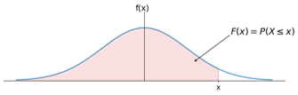

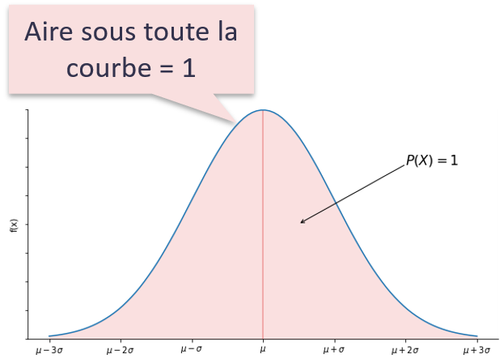

Similairement à la recherche de la probabilité de l’évènement contraire, on peut trouver la probabilité $\mathbb{P}(X > a)$ comme suit :
$$\mathbb{P}(X > a) = 1 - \mathbb{P}(X \leq
a)$$

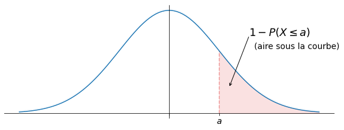

#### Caractérisation de la loi d’une v.a.r. continue par la fonction de densité

Notons que la fonction de densité $f(x)$ caractérise la loi d’une v.a.r. absolument continue $X$. Ainsi, dans le cas d’une v.a.r. discrète $X$ définie sur $(\Omega, \mathcal{A}, \mathbb{P})$ avec $A$ étant un borélien de $\mathbb{R}$:
$$\mathbb{P}_X(A) = \int_{A}f_X(t)dt =
\int_{\mathbb{R}}f_X(t)\times \mathbb{I}_A(t)dt$$

### Exemple de calcul

Prenons l’exemple proposé dans (Orloff and Bloom 2014).

La v.a. $X$ est définie sur l’intervalle $[0,2]$ par la fonction de densité $f(x) = cx^2$.

1. Quelle est la valeur de $c$ ?
2. Quelle est la fonction de répartition $F(x)$ ?
3. Quelle est la probabilité $\mathbb{P}(1\leq X \leq 2)$ ?

**Solution**

#### 1. Quelle est la valeur de $c$ ?

La somme des probabilités sur tout l’intervalle $[a,b]$ sur lequel $X$ est défini doit être $égale à 1$, i.e. $\int_a^b f(x)dx = 1$. Dans notre cas, $X$ est défini sur $[0,2]$. Alors :

$$\int_a^b f(x)dx = \int_0^2 cx^2 dx =
c\frac{x^3}{3}\Bigg\rvert_{0}^2 = c\frac{8}{3} - 0 = c\frac{8}{3} =
1$$
D’où $c = \mathbf{\frac{3}{8}}$.

En remplaçant $c$ par cette valeur, on obtient $f(x) = \frac{3}{8}x^2$.

#### 2. Quelle est la fonction de répartition $F(x)$ ?

Pour rappel, la fonction de répartition est donné par $F(x) = \mathbb{P}(X\leq x) = \int_{-\infty}^x f(t)dt$. Ainsi, en sachant $f(x)$, on peut trouver $F(x)$.

Notons que par définition, la fonction de densité $f(x)=0$ en dehors de l’intervalle sur lequel $X$ est défini. Dans notre cas, on peut réécrire $f(x)$ de la façon suivante :
$$f(x) = \left\{
\begin{array}{ll} 0, \mbox{ si } x < 0 \\ \frac{3}{8}x^2, \mbox{ si }
x\in [0,2] \\ 0, \mbox{ si } x>2 \end{array} \right.$$
Donc, la fonction de répartition $F(x) = 0, \mbox{ si } x<0$ et $F(x) = 1, \mbox{ si } x>2$. Il reste donc trouver la fonction de répartition pour $x\in [0, 2]$.

$$F(x) = \int_{-\infty}^x f(t)dt =
\int_{\mathbf{0}}^x ct^2dt = c\frac{t^3}{3}\Bigg\rvert_{0}^x =
c\frac{x^3}{3} = \frac{3}{8}\cdot\frac{x^3}{3} = \frac{x^3}{8} =
\left(\frac{x}{2}\right)^3$$
Alors, en rassemblant tout :

$$F(x) = \left\{ \begin{array}{ll} 0,
\mbox{ si } x < 0 \\ \left(\frac{x}{2}\right)^3, \mbox{ si } x\in
[0,2] \\ 1, \mbox{ si } x>2 \end{array} \right.$$

#### 3. Quelle est la probabilité $\mathbb{P}(1\leq X \leq 2)$ ?

On peut aborder le calcul de $\mathbb{P}(a\leq X\leq b)$ de deux façons :

1. $\mathbb{P}(a\leq X\leq b) = \int_a^b f(x)dx$
2. $\mathbb{P}(a\leq X\leq b) = F(b) - F(a)$

Essayons les deux options.

##### 3.1. Option 1 : $\mathbb{P}(a\leq X\leq b) = \int_a^b f(x)dx$

$$\mathbb{P}(1\leq X\leq 2) = \int_1^2
cx^2 dx = c\frac{x^3}{3}\Bigg\rvert_{1}^2 =
\frac{3}{8}\cdot\frac{x^3}{3}\Bigg\rvert_{1}^2 =
\frac{x^3}{8}\Bigg\rvert_{1}^2 = \frac{8}{8} - \frac{1}{8} =
\mathbf{\frac{7}{8}}$$

##### 3.2. Option 2 : $\mathbb{P}(a\leq X\leq b) = F(b) - F(a)$

Notons que $1\in [0,2]$ et $2\in [0,2]$. Sur l’intervalle en question, la fonction de répartition prend la forme $F(x) = \left(\frac{x}{2}\right)^3$. Donc :

$$\mathbb{P}(1\leq X\leq 2) = F(2) - F(1)
= \left(\frac{2}{2}\right)^3 - \left(\frac{1}{2}\right)^3 = 1 -
\frac{1}{8} = \mathbf{\frac{7}{8}}$$

## Bilan

Résumons les notions de la loi de probabilité de la façon suivante :

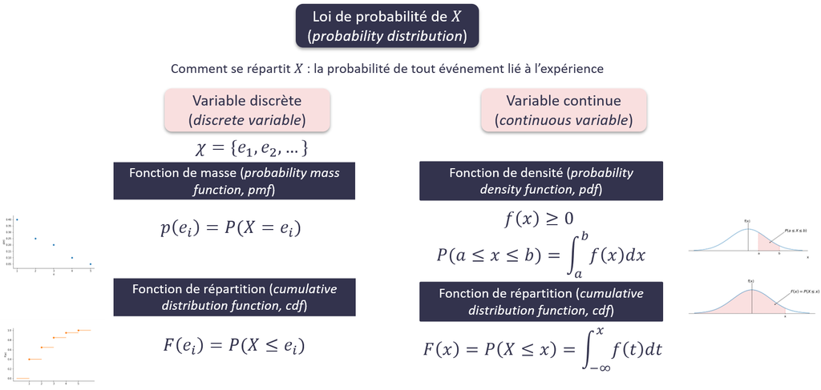

# Moments d’une variable aléatoire

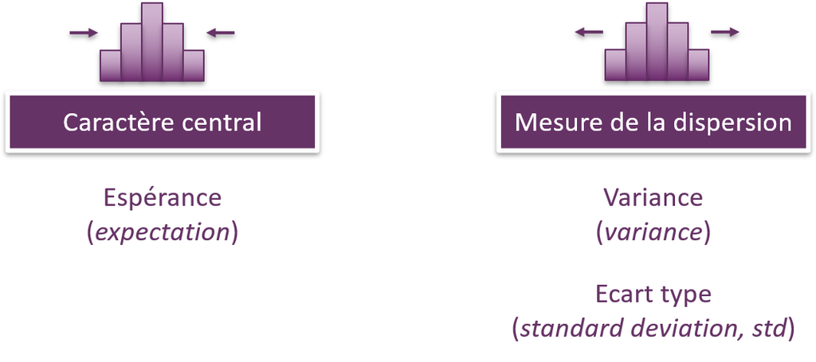

## Espérance

**L’espérance** (en. *expectation* ou *expected value* ou *mean* ou *average* ou *first moment*) d’une v.a.r. $X$, notée $\mathbb{E}X$ ou $\mathbb{E}[X]$ ou $\mathbb{E}(X)$ est une généralisation de la valeur moyenne pondérée.

Son calcul (lorsque cette quantité existe) dépend de la nature de $X$ :

- v.a.r. discrète :
  $$\mathbb{E}[X] =
  \sum_i x_ip_i = \sum_i x_iP(X=x)$$
- v.a.r. continue :
  $$\mathbb{E}[X] =
  \int_{-\infty}^{+\infty}tf(t)dt$$
  Notons que ces définitions peuvent être généralisées pour l’espérance d’une v.a.r. $g(X)$, où $g : X(\Omega) \rightarrow \mathbb{R}$ :
- cas dicret : $\mathbb{E}[g(X)] = \sum_i g(x_i)p_i = \sum_i g(x_i)P(X=x)$
- cas contiue : $\mathbb{E}[g(X)] = \int_{-\infty}^{+\infty}g(t)f(t)dt$

**Propriétés :**

- $\mathbb{E}[X] \geq 0$
- $\mathbb{E}[X + Y] = \mathbb{E}[X] + \mathbb{E}[Y]$
- $\mathbb{E}[aX + b] = a\mathbb{E}[X] + b$

Notons que ces résultats peuvent être généralisés pour l’espérance d’une v.a.r. $g(X)$, où $g : X(\Omega) \rightarrow \mathbb{R}$ :

- $\mathbb{E}[g(X)] \geq 0$
- $\mathbb{E}[g_1(X) + g_2(X)] = \mathbb{E}[g_1(X)] + \mathbb{E}[g_2(X)]$
- $\mathbb{E}[ag(X)] = a\mathbb{E}[g(X)] + b$
- soit $X$ une v.a.r. continue, $g_1$ et $g_2$ deux fontions t.q. $g_1 \leq g_2$, alors $\mathbb{E}[g_1(X)] \leq \mathbb{E}[g_2(X)]$
- si $X$ est une v.a.r. constante sur $\Omega$ et $g$ une fonction quelconque, alors $\mathbb{E}[g(X)] = g(X)$

Les démonstrations de ces propriétés peuvent être trouvées dans Stéphane Balac and Mazet (n.d.).

Une autre propriété peut être formulée sous forme de l’*inégalité de Markov* :

**Inégalité de Markov** : Soit $X$ une v.a.r. Alors :
$$\forall a> 0, a\in \mathbb{R} : \
\ \mathbb{P}(|X|\geq a) \leq \frac{1}{a} \mathbb{E}[|X|]$$

**Exemple :** Si chaque fois que vous obtenez *face* en lançant une pièce, vous gagnez 5 euros, et chaque fois que vous obtenez *pile*, vous perdez 5 euros. Quelle est le gain moyen ou autrement dit, l’espérance de gain ?

$$\mathbb{E}[X] = \sum_i x_ip_i = \sum_i
x_iP(X=x) = 5\times \frac{1}{2} + (-5)\times \frac{1}{2} =
\mathbf{0}$$
En moeyenne, on gagne rien.

## Variance et écart-type

**La variance** (en. *variance*) de la v.a.r. $X$, notée $Var(X)$ ou $\sigma^2$, est une mesure de la dispersion de données autour de son espérance $\mathbb{E}X$.

Son calcul (lorsque cette quantité existe) dépend de la nature de $X$ :

- v.a.r. discrète :
  $$Var(X) =
  \mathbb{E}[(X-\mathbb{E}X)^2]=\mathbb{E}[X^2]-(\mathbb{E}X)^2=\sum_i
  (x_i-\mathbb{E}X)^2 p_i$$
- v.a.r. continue :
  $$Var(X) =
  \mathbb{E}[(X-\mathbb{E}X)^2]=\mathbb{E}[X^2]-(\mathbb{E}X)^2=\int_{a}^{b}(x-\mathbb{E}X)^2f(x)dx$$

**Propriétés :**

- $Var(X) \geq 0$
- $Var(X + Y) = Var[X] + Var[Y]\mbox{, (si } X\mbox{ et } Y\mbox{ indép.)}$
- $Var(aX + b) = a^2Var(X)$

**L’écart-type** (en. *standard deviation, std*) de la v.a.r. $X$, noté $\sqrt{Var(X)}$ ou $\sigma$, est une mesure de l’écart entre les valeurs prises par $X$ et son espérance $\mathbb{E}X$

$\sigma(X)=\sigma_X = \sqrt{Var(X)}$

Remarquons qu’il existe d’autres propriétés, dont une peut être formulée sous forme de l’*inégalité de Bienaymé-Tchebychev* :

**Inégalité de Bienaymé-Tchebychev** : Soit $X$ une v.a.r. Alors :
$$\forall \alpha > 0, \alpha\in \mathbb{R} : \ \
\mathbb{P}(|X - \mathbb{E}X|\geq \alpha) \leq
\frac{Var(X)}{\alpha^2}$$

## Moments de l’ordre $p$

De la façon plus généralle, on peut définir les moments comme suit :

**Un moment d’ordre $p\ (p\in \mathbb{N})$** de la v.a.r. $X$ est un nombre réel $\mathbb{E}(|X|^p)$, quand il existe.

**Un moment centré d’ordre $p\ (p\in \mathbb{N})$** de la v.a.r. $X$ est un nombre réel $\mathbb{E}(|X - \mathbb{E}X|^p)$, quand il existe.

## Exemple de calcul

Soit $X$ une v.a. définie par les valeurs ci-dessous. Calculez sa variance et son écart-type.

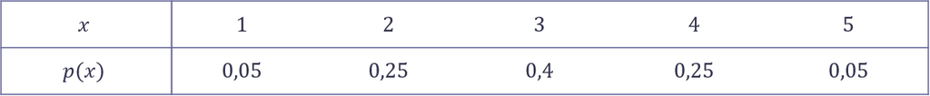

Il s’agit d’une v.a. discrète. Vérifions que $\sum_{i=1}^n p(x_i) = 1$ :

$$\sum_{i=1}^n p(x_i) = 0.05 + 0.25 + 0.4
+ 0.25 + 0.05 = 1$$

La variance d’une v.a. discrète est donnée par :

$$Var(X) =
\mathbb{E}[(X-\mathbb{E}X)^2]=\mathbb{E}[X^2]-(\mathbb{E}X)^2=\sum_i
(x_i-\mathbb{E}X)^2 p_i$$

et son écart-type est défini comme $\sigma(X) = \sqrt{Var(X)}$.

Ainsi, on peut voir que afin de calculer la variance et l’écart-type, il faut d’abord calculer l’espérance de $X$, $\mathbb{E}X$, donnée par :
$$\mathbb{E}[X] = \sum_i x_ip_i = \sum_i
x_iP(X=x)$$

$$\mathbb{E}[X] = 1\times 0.05 + 2\times
0.25 + 3\times 0.4 + 4\times 0.25 + 5\times 0.05 = 0.05 + 0.5 + 1.2 + 1
+ 0.25 = 3$$
.

Soustrayons l’espérance de $X$ à partir des valeurs de $X$ et rajoutons une nouvelle ligne dans la table :

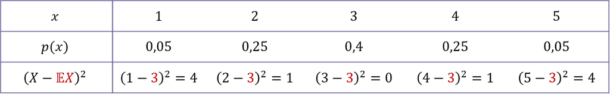

Nous pouvons néanmoins appliquer la formule de la variance en multipliant les probabilités de chaque valeurs par le nouveau terme qu’on vient de calculer et en prenant leur somme :

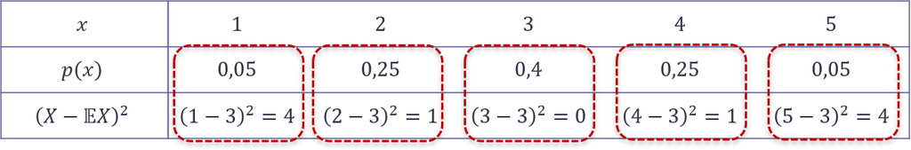

$$Var(X) = \mathbf{4}\times 0.05 +
\mathbf{1}\times 0.25 + \mathbf{0}\times 0.4 + \mathbf{1}\times 0.25 +
\mathbf{4}\times 0.05 = 0.2 + 0.25 + 0 + 0.25 + 0.2 =
\mathbf{0.9}$$

Une fois la variance est calculée, il est possible de calculer l’écart-type :

$$\sigma(X) = \sqrt{Var(X)} =
\mathbf{\sqrt{0.9}}$$

# Quelques exemples de lois de probabilité

Citons quelques examples de lois de probabilité.

## Distribution normale

**La loi normale** aussi appelée **la loi de Gauss** (en. *Normal distribution*) est une loi de probabilité très étudiée et très utilisée.

La notation suivante est utilisée : $X\sim \mathcal{N}(m, \sigma^2)$ ou $X\sim \mathcal{N}(\mu, \sigma^2)$ pour exprimer que la v.a.r. $X$ sur l’espace probabilisé $(\Omega, \mathcal{A}, \mathbb{P})$ suit la loi normale avec les paramètres $(m, \sigma^2)$ (ou $(\mu, \sigma^2)$). Le paramètre $m$ ($\mu$) est l’espérance de la distribution et le paramètre $\sigma^2$ et la variance ($\sigma$ est l’écart-type).

La loi normale est définie par *la fonction de densité* suivante :

$$f(x) = \frac{1}{\sigma\sqrt{2\pi}}
e^{-1/2\left(\frac{x-m}{\sigma}\right)^2}$$

*La fonction de répartition de la loi normale* est donc donnée par :
$$F(x) =
\frac{1}{\sigma\sqrt{2\pi}}\int_{-\infty}^x
e^{-1/2\left(\frac{t-m}{\sigma}\right)^2}dt$$

La courbe de la fonction de densité a la forme dite de “cloche” et elle est symétrique par rapport à $m$ :

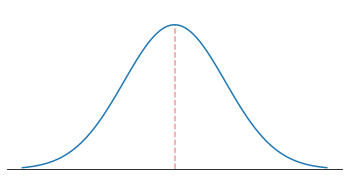

Soit $X\sim \mathcal{N}(\mu, \sigma^2)$. On peut remarquer les régularités suivantes :

- $\mathbb{P}(\mu - \sigma\leq X \leq \mu + \sigma) \approx 0.682$
- $\mathbb{P}(\mu - 2\sigma\leq X \leq \mu + 2\sigma) \approx 0.954$
- $\mathbb{P}(\mu - 3\sigma\leq X \leq \mu + 3\sigma) \approx 0.997$

ou sur le graphique :

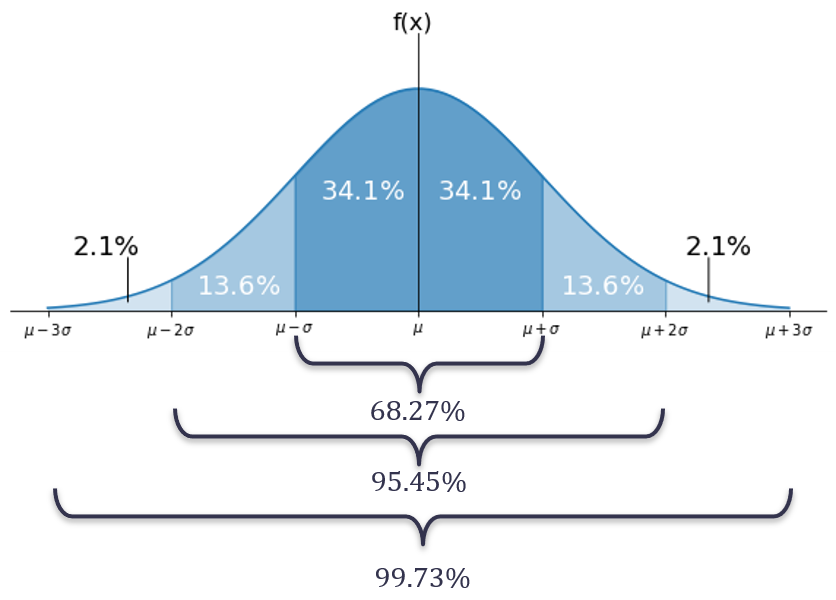

Observons maintenant deux courbes :

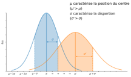

Selon la forme et la position des centres, on peut déduire que : $\mu' > \mu$ (le centre est situé plus à droite) et $\sigma' > \sigma$ (la courbe est plus étalée).

### Loi normale centrée réduite

Un cas spécial de la loi normale est **la loi normale centrée réduite** (en. *standard normal distribution*). Il s’agit de la loi normale avec les paramètres $(0,1)$, i.e. : $X\sim \mathcal{N}(0, 1)$, autrement dit $m=0$, $\sigma=1$.

Sa *fonction de densité* est :

$$\varphi =
\frac{1}{\sqrt{2\pi}}e^{-x^2/2}$$

Visualisons-la :

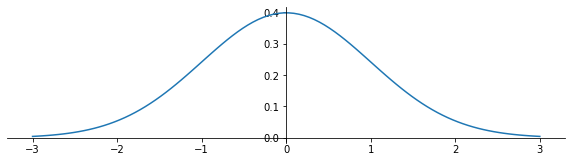

Sa *fonction de répartition* est donnée par :

$$\Phi = \frac{1}{\sqrt{2\pi}}
\int_{-\infty}^x e^{-t^2/2}dt$$

En la visualisant :

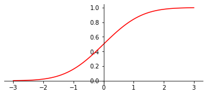

Dans le `R`:

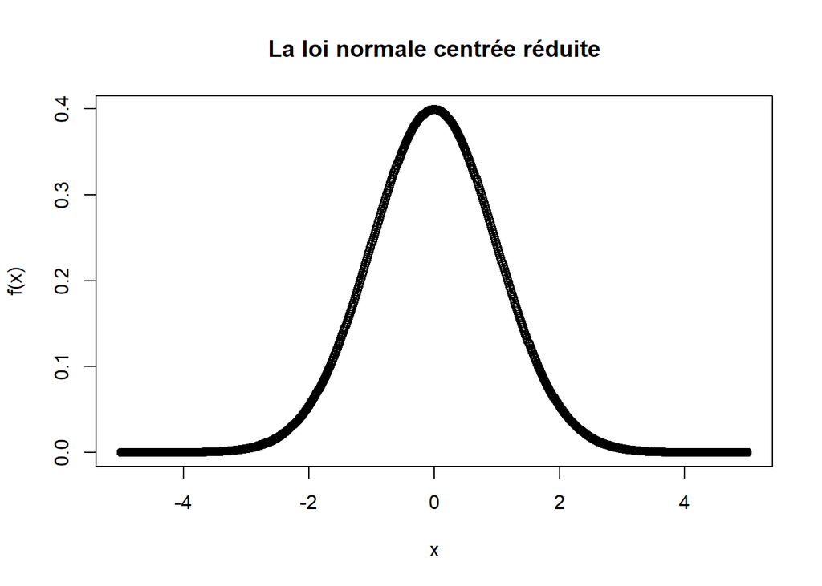

```r
# création d'une séquence de valeurs dans la plage [-5,5] avec le pas 0.01
x <- seq(-5, 5, 0.01)
# les valeurs de la fonction de densité de la loi normale centrée réduite
# pour les x
y <- dnorm(x, mean=0, sd=1)
# visualisation de (x, y)
plot(x, y, main="La loi normale centrée réduite", ylab="f(x)")
```

### Z-table

Une des particularités de la loi normale est que les valeurs numériques prises par sa fonction de répartition sont tabulées.

> Comment trouver la valeur de $\Phi(x)$ ?

Comme il est indiqué plus haut, les valeurs de la loi normale centrée réduite $\Phi(x) = \mathbb{P}(X\leq x)$ sont connues et on peut les trouver dans les tables.

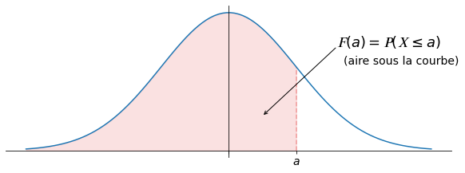

Observons la table de la loi normale centrée réduite.

[interactive table not shown]

Supposons qu’on s’intéresse à $\Phi(1.53)$.

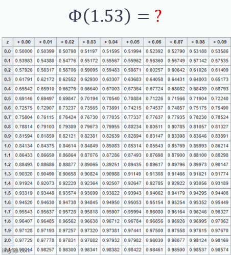

Ainsi, on retrouve la valeur $\Phi(1.53) = 0.93699$.

Pour trouver la valeur de la fonction de répartition de la loi normale centrée réduite, on peut également utiliser la fonction `pnorm(x, mean=0, sd=1)` de `R`. Reprenons le même exemple de $\Phi(1.53)$ :

```r
# x=1.53
pnorm(1.53, mean=0, sd=1)
```

```
## [1] 0.9369916
```

On obtient le même résultat.

**Et si on s’intéresse à une valeur négative ?**

Dans ce cas là, grâce à la symétrie de la loi normale, on peut utiliser la propriété suivante : pour $x < 0$, $\Phi(x) = 1 - \Phi(|x|)$.

Regardons sur l’exemple de $x = -2$.

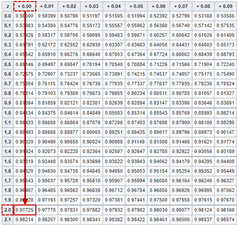

Dans le `R` :

```r
# x=-2
pnorm(-2, mean=0, sd=1)
```

```
## [1] 0.02275013
```

```r
# x=2
pnorm(2, mean=0, sd=1)
```

```
## [1] 0.9772499
```

```r
# 1-F(2)
1-pnorm(2, mean=0, sd=1)
```

```
## [1] 0.02275013
```

```r
# vérifions que F(-2) == 1-F(2) en arrondissant pour éviter les différences
# dans la précision de valeurs
round(pnorm(-2, mean=0, sd=1), 8) == round(1-pnorm(2, mean=0, sd=1), 8)
```

```
## [1] TRUE
```

### Normalisation (standartisation)

> Comment trouver la valeur de $\mathbb{P}(X \leq x), \ X\sim \mathcal{N}(m, \sigma^2)$ si ce sont des valeurs de la loi normale centrée réduite qui sont tabulée ?

Soit $X\sim \mathcal{N}(m, \sigma^2)$. Introduisons la v.a.r. $Z$ telle que :

$$Z = \frac{X-m}{\sigma}$$

Cette nouvelle v.a.r. suit la loi normale centrée réduite, i.e. $Z\sim \mathcal{N}(0,1)$.

Le processus de création de $Z$ est appelé **standartisation** ou **normalisation** (en. *normalisation* ou *standartisation*).

Notons une propriété importante :

$$\mathbb{P}(X \leq x) =
\mathbb{P}\left(\frac{X-m}{\sigma}\leq\frac{x-m}{\sigma}\right) =
\mathbb{P}\left(Z\leq \frac{x-m}{\sigma}\right)$$
Alors, en se servant de la table des valeurs pour la loi normale centrér réduite, on peut trouver $\mathbb{P}(X \leq x)$.

## Autres lois de probabilité

Présentons ici quelques lois de probabilité avec leurs caractéristiques principales.

### Variables discrètes

|  | Plage ds valeurs | Fonction de masse | Visualisation | Espérance | Variance | Interprétation |
| --- | --- | --- | --- | --- | --- | --- |
| **Uniforme discrète**, $\mathcal{U}(N)$ | $\{1,...,N\}$ | $$\mathbb{P}(X=k) = \frac{1}{N}$$ |  | $\frac{N+1}{2}$ | $\frac{N^2-1}{12}$ | $N$ issues équiprobables |
| **Bernoulli**, $\mathcal{B}(p)$ | $\{0,1\}$ | $$\mathbb{P}(X=k) = \left\{\begin{array}{ll}1-p, \mbox{ si } k=0 \\ p, \mbox{ si } k=1 \\ 0, \mbox{ sinon}\end{array}\right.$$ |  | $p$ | $p(1-p)$ | 2 issues possibles dont une avec la probabilité $p$ |
| **Binomiale**, $\mathcal{B}(n,p)$ | $\{0,...,n\}$ | $$\mathbb{P}(X=k) = C^k_n p^k(1-p)^{n-k}$$ |  | $np$ | $np(1-p)$ | Somme de $n$ Bernoullis indépendants : # succès dans $n$ tirages si chaque tirage a une probabilité $p$ d’être gagnant (e.g. # tickets gagnant parmi $n$) |
| **Géométrique**, $\mathcal{G}(p)$ | $\{0,...,\infty\}$ | $$\mathbb{P}(X=k) = p(1-p)^{k-1}$$ |  | $\frac{1}{p}$ | $\frac{1-p}{p^2}$ | # tirages avant le 1er succès dans une séquence de Bernoullis indépendants (e.g. # piles avant la 1ère face) |
| **Poisson**, $\mathcal{P}(\lambda)$ | $\{0,...,\infty\}$ | $$\mathbb{P}(X=k) = e^{-\lambda\frac{\lambda^k}{k!}}$$ |  | $\lambda$ | $\lambda$ | Evènements rares : une réalisation sur un grand nombre d’expériences |

### Variables continues

|  | Plage ds valeurs | Densité | Visualisation | Espérance | Variance | Interprétation |
| --- | --- | --- | --- | --- | --- | --- |
| **Uniforme**, $\mathcal{U}([a,b])$ | $[a,b]$ | $$f(x) = \frac{1}{b-a}\mathbb{I}_{[a,b]}(x)$$ $\mathbb{I}_{A}(x) = \left\{\begin{array}{ll} 1, \mbox{ si } x\in A \\ 0, \mbox{ sinon} \end{array} \right.$ |  | $\frac{a+b}{2}$ | $\frac{(b-a)^2}{12}$ | Toutes les valeurs ont la même chance d’apparaître (permutation aléatoire uniforme) |
| **Normale, Gausienne, Laplace-Gauss**, $\mathcal{N}(m,\sigma^2)$ | $\mathbb{R}$ | $$f(x) = \frac{1}{\sigma\sqrt{2\pi}} e^{-1/2\left(\frac{x-m}{\sigma}\right)^2}$$ |  | $m$ | $\sigma^2$ | Loi des moyennes |
| **Exponentielle**, $\mathcal{E}(\lambda)$ | $\mathbb{R}^{+}$ | $$f(x) = \lambda e^{-\lambda x}\mathbb{I}_{\mathbb{R}^{+}}(x)$$ |  | $\frac{1}{\lambda}$ | $\frac{1}{\lambda^2}$ | Loi des durés de vie / réalisations de tâches |

# Fonction caractéristique et fonction génératrice

> Soit $X$ v.a.r. de la loi connue, soit $h : \mathbb{R} \rightarrow \mathbb{R}$ fonction continue par morceaux. Quelle est la loi de la v.a.r. $X$ ?

Afin de pouvoir répondre à ce genre de problèmes, d’autres caractérisations de la loi d’une v.a.r. à part la fonction de masse / densité peuvent être utiles.

Ici, nous présenterons brièvemet la fonction caractéristique et la fonction génératrice. Pour plus de détails, voir Stéphane Balac and Mazet (n.d.).

## Fonction caractéristique

On appelle **la fonction caractéristique** de la v.a.r. $X$ la fonction de $\mathbb{R}$ dans $\mathbb{C}$ définie par
$$\phi_X(t) = \mathbb{E}(e^{itX}), \ \forall t\in
\mathbb{R}$$

*Quelques propriétés* :

- Si $\phi_X(t)$ est deux fois dérivable en 0, alors $\mathbb{E}(X)$ et $\mathbb{E}(X^2)$ existent et :

$$\mathbb{E}(X) =
-i\phi'_X(0)$$
$$\mathbb{E}(X^2) =
-\phi''_X(0)$$

- Soit $a$ et $b$ deux réels et $Y$ la v.a.r. définie par $Y = aX + b$. La fonction caractéristique $\phi_Y(t)$ de la v.a.r. $Y$ vérifie :

$$\phi_Y(t) = e^{itb}\phi_X(at), \ \forall
t\in \mathbb{R}$$

## Fonction génératrice

Soit $X$ v.a.r. discrète à valeurs entières. On appelle **fonction génératrice de $X$** la fonction définie pour tout $s\in [-1,1]$ par
$$G_X(s) = \mathbb{E}(s^X) = \sum_{j\in
\mathbb{N}}s^j \times \mathbb{P}(X=j)$$

*Quelques propriétés* :

- $G_X(1) = 1$, $G_X(0) = \mathbb{P}(X=0)$
- $G'_X(1) = \mathbb{E}(X)$, $G''_X(1) = \mathbb{E}(X(X-1))$ et plus généralement : $\forall k\in \mathbb{N}^*,$

$$G^{(k)}_X(1) = \mathbb{E}(X\times
(X-1)\times ...\times (X-k+1))$$

# Liens utiles

1. Jeremy Orloff, and Jonathan Bloom. *18.05 Introduction to Probability and Statistics*. Spring 2014. Massachusetts Institute of Technology: MIT OpenCourseWare, https://ocw.mit.edu. License: Creative Commons BY-NC-SA.
2. [Combinaisons avec répétition](https://www.youtube.com/watch?v=1crNnZkIvac)
3. [Z-table](https://www.ztable.net/)

# References

Orloff, Jeremy, and Jonathan Bloom. 2014. “18.05 Introduction to Probability and Statistics. MIT OpenCourseWare.” 2014. https://ocw.mit.edu/courses/mathematics/18-05-introduction-to-probability-and-statistics-spring-2014/.

Stéphane Balac, and Olivier Mazet. n.d. “Introduction aux Probabilités.” Centre de Mathématiques. Institut National des Sciences Appliquées de Lyon. Accessed May 13, 2021. https://perso.univ-rennes1.fr/stephane.balac/publis/polypbs.pdf.